# IDS investigation worksheet

the RegRession Rebels: Kenny, Jake, Matthew, Sarah & Alex

2023-11-29

**Note:** You can use this file as you ‘working document’ where you can try out various investigation ideas and keep notes about your findings. How you use and structure this file is up to you. It is recommended that you keep notes about what you are investigating and what you find as this will make the process of creating your presentation and report easier. Please note that you *do not* need to submit this file as part of your group project.

```r
library(tidyverse)
library(readxl)
library(tidymodels)
```

just a bit of loading data here

```r
# Cleaning the data sets

diagnosis <- read_csv("data/mental-health-inpatient-activity-diagnosis-trend.csv", show_col_types = FALSE)

deprivation <- read_csv("data/mental-health-inpatient-activity-deprivation.csv", show_col_types = FALSE)

age_and_sex <- read_csv("data/mental-health-inpatient-activity-age-sex.csv", show_col_types = FALSE)

icd_10_codes <- read_xlsx("data/icd10-lookup.xlsx")
```

This chunk is for translating all data/codes into readable categories based on their respective charts.

```r
diagnosis_BUT_READABLE <- diagnosis %>%
  mutate(icd_categories = case_when(
    ICD10Codes == "F00 - F09 or Chapter G and second position F00" ~ "Organic, including symptomatic, mental disorders",
    ICD10Codes == "F10 - F19" ~ "Mental & behavioural disorders due to psychoactive substance use",
    ICD10Codes == "F20 - F29" ~ "Schizophrenia, schizotypal, & delusional disorders",
    ICD10Codes == "F30 - F39" ~ "Mood (affective) disorders",
    ICD10Codes == "F40 - F49" ~ "Neurotic, stress-related, & somatoform disorders",
    ICD10Codes == "F60 - F69" ~ "Disorders of adult personality & behaviour",
    ICD10Codes == "F50 - F59, F70 - F99" ~ "Other selected diagnoses principally affecting children & young people",
    ICD10Codes == "Non-F codes" ~ "Unrecognized diagnosis",
                       .default = ICD10Codes )) %>%
  select(!ICD10Codes)

diagnosis_BUT_READABLE <- diagnosis_BUT_READABLE %>%
  mutate(smr_translated = case_when(
    Dataset == "SMR00" ~ "Outpatients",
    Dataset == "SMR01" ~ "General/Acute Inpatients/Day Cases (including Geriatric Long Stay Inpatients)",
    Dataset == "SMR02" ~ "Maternity Inpatients/Day Cases",
    Dataset == "SMR04" ~ "Mental Health Inpatients/Day Cases",
              .default = Dataset )) %>%
  select(!Dataset)

diagnosis_BUT_READABLE <- diagnosis_BUT_READABLE %>%
  select(
    FinancialYear, HBT, DischargeCount, DischargeRates, PatientsCount,
    PatientsRates,HospitalResidentsCount, HospitalResidentsRates,
    icd_categories, smr_translated) %>%
  mutate(DischargeRates = DischargeRates / 100000, PatientsRates = PatientsRates / 100000)

diagnosis_BUT_READABLE <- diagnosis_BUT_READABLE %>%
  mutate(hbt_translated = case_when(
    HBT == "S92000003" ~ "Scotland",
    HBT == "S08000015" ~ "Ayrshire and Arran",
    HBT == "S08000016" ~ "Borders",
    HBT == "S08000017" ~ "Dumfries and Galloway",
    HBT == "S08000018" ~ "Fife",
    HBT == "S08000019" ~ "Forth Valley",
    HBT == "S08000020" ~ "Grampian",
    HBT == "S08000021" ~ "Greater Glasgow and Clyde",
    HBT == "S08000022" ~ "Highland",
    HBT == "S08000023" ~ "Lanarkshire",
    HBT == "S08000024" ~ "Lothian",
    HBT == "S08000025" ~ "Orkney",
    HBT == "S08000026" ~ "Shetland",
    HBT == "S08000027" ~ "Tayside",
    HBT == "S08000028" ~ "Western Isles",
    HBT == "S08000029" ~ "Fife",
    HBT == "S08000030" ~ "Tayside",
    HBT == "S08000031" ~ "Greater Glasgow and Clyde",
    HBT == "S08000032" ~ "Lanarkshire",
              .default = HBT)) %>%
  select(!HBT)

deprivation_BUT_READABLE <- deprivation %>%
  mutate(smr_translated = case_when(
    Dataset == "SMR00" ~ "Outpatients",
    Dataset == "SMR01" ~ "General/Acute Inpatients/Day Cases (including Geriatric Long Stay Inpatients)",
    Dataset == "SMR02" ~ "Maternity Inpatients/Day Cases",
    Dataset == "SMR03" ~ "Scottish Index of Deprivation",
    Dataset == "SMR04" ~ "Mental Health Inpatients/Day Cases",
              .default = Dataset )) %>%
  select(!Dataset)

deprivation_BUT_READABLE <- deprivation_BUT_READABLE %>%
  mutate(hbr_translated = case_when(
    HBR == "S92000003" ~ "Scotland",
    HBR == "S08000015" ~ "Ayrshire and Arran",
    HBR == "S08000016" ~ "Borders",
    HBR == "S08000017" ~ "Dumfries and Galloway",
    HBR == "S08000018" ~ "Fife",
    HBR == "S08000019" ~ "Forth Valley",
    HBR == "S08000020" ~ "Grampian",
    HBR == "S08000021" ~ "Greater Glasgow and Clyde",
    HBR == "S08000022" ~ "Highland",
    HBR == "S08000023" ~ "Lanarkshire",
    HBR == "S08000024" ~ "Lothian",
    HBR == "S08000025" ~ "Orkney",
    HBR == "S08000026" ~ "Shetland",
    HBR == "S08000027" ~ "Tayside",
    HBR == "S08000028" ~ "Western Isles",
    HBR == "S08000029" ~ "Fife",
    HBR == "S08000030" ~ "Tayside",
    HBR == "S08000031" ~ "Greater Glasgow and Clyde",
    HBR == "S08000032" ~ "Lanarkshire",
              .default = HBR )) %>%
  select(!HBR)

deprivation_BUT_READABLE <- deprivation_BUT_READABLE %>%
  select(
    FinancialYear, hbr_translated, SIMD, smr_translated, DischargeCount, DischargeRates,
    PatientsCount, PatientsRates,HospitalResidentsCount, HospitalResidentsRates) %>%
  mutate(DischargeRates = DischargeRates / 100000, PatientsRates = PatientsRates / 100000)


age_and_sex_BUT_READABLE <- age_and_sex %>% mutate(hbr_translated = case_when(
HBR == "S92000003" ~ "Scotland",
HBR == "S08000015" ~ "Ayrshire and Arran",
HBR == "S08000016" ~ "Borders",
HBR == "S08000017" ~ "Dumfries and Galloway",
HBR == "S08000018" ~ "Fife",
HBR == "S08000019" ~ "Forth Valley",
HBR == "S08000020" ~ "Grampian",
HBR == "S08000021" ~ "Greater Glasgow and Clyde",
HBR == "S08000022" ~ "Highland",
HBR == "S08000023" ~ "Lanarkshire",
HBR == "S08000024" ~ "Lothian",
HBR == "S08000025" ~ "Orkney",
HBR == "S08000026" ~ "Shetland",
HBR == "S08000027" ~ "Tayside",
HBR == "S08000028" ~ "Western Isles",
HBR == "S08000029" ~ "Fife",
HBR == "S08000030" ~ "Tayside",
HBR == "S08000031" ~ "Greater Glasgow and Clyde",
HBR == "S08000032" ~ "Lanarkshire",
.default = HBR
)) %>% select(!HBR)

age_and_sex_BUT_READABLE <- age_and_sex_BUT_READABLE %>%
  select(
    FinancialYear, AgeGroup, Sex, hbr_translated, DischargeCount, DischargeRates, PatientsCount,
    PatientsRates)
```

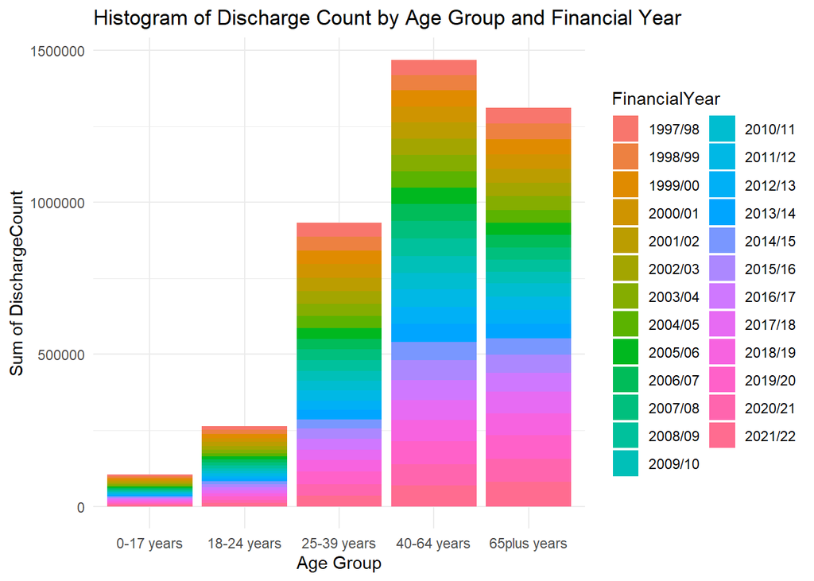

```r
# Initial Visualizations
# age group
age_and_sex_BUT_READABLE %>%
  group_by(FinancialYear, AgeGroup) %>%
  summarise(Sum_DischargeCount = sum(DischargeCount, na.rm = TRUE), .groups = "keep") %>%

  ggplot(mapping = aes(x = AgeGroup, y = Sum_DischargeCount, fill = FinancialYear)) +
  geom_col() +
  labs(title = "Histogram of Discharge Count by Age Group and Financial Year",
       x = "Age Group",
       y = "Sum of DischargeCount") +
  theme_minimal()
```

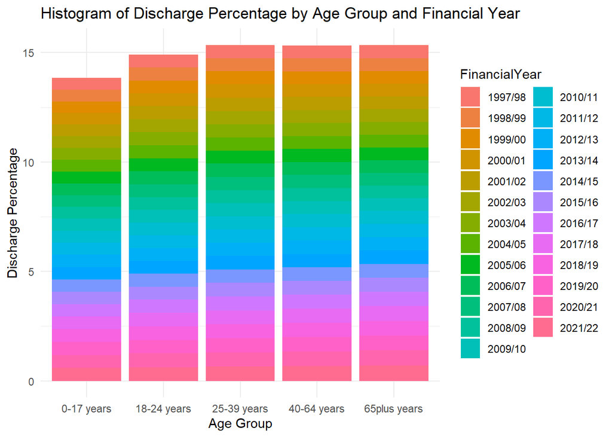

```r
age_and_sex_BUT_READABLE %>%
  mutate(TotalPatientsCount = DischargeCount + PatientsCount)  %>%
  group_by(FinancialYear, AgeGroup) %>%
  summarise(DischargeCountPercentage = sum(DischargeCount) / sum(TotalPatientsCount, na.rm = TRUE), .groups = "keep") %>%

  ggplot(mapping = aes(x = AgeGroup, y = DischargeCountPercentage, fill = FinancialYear)) +
  geom_col() +
  labs(title = "Histogram of Discharge Percentage by Age Group and Financial Year",
       x = "Age Group",
       y = "Discharge Percentage") +

  theme_minimal()
```

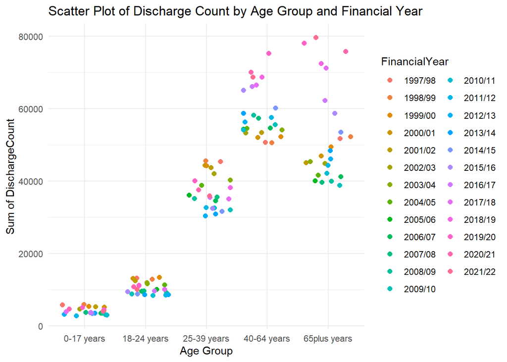

```r
age_and_sex_BUT_READABLE %>%
  group_by(FinancialYear, AgeGroup) %>%
  summarise(Sum_DischargeCount = sum(DischargeCount, na.rm = TRUE), .groups = "keep") %>%

  ggplot(mapping = aes(x = AgeGroup, y = Sum_DischargeCount, color = FinancialYear)) +
  geom_jitter(size = 2) +
  labs(title = "Scatter Plot of Discharge Count by Age Group and Financial Year",
       x = "Age Group",
       y = "Sum of DischargeCount",
       color = "FinancialYear") +
  theme_minimal()
```

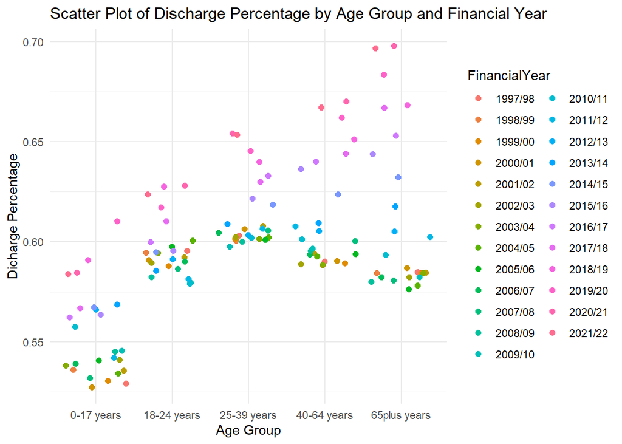

```r
age_and_sex_BUT_READABLE %>%
  mutate(TotalPatientsCount = DischargeCount + PatientsCount)  %>%
  group_by(FinancialYear, AgeGroup) %>%
  summarise(DischargeCountPercentage = sum(DischargeCount) / sum(TotalPatientsCount, na.rm = TRUE), .groups = "keep") %>%

  ggplot(mapping = aes(x = AgeGroup, y = DischargeCountPercentage, color = FinancialYear)) +
  geom_jitter(size = 2) +
  labs(title = "Scatter Plot of Discharge Percentage by Age Group and Financial Year",
       x = "Age Group",
       y = "Dicharge Percentage",
       color = "FinancialYear") +

  theme_minimal()
```

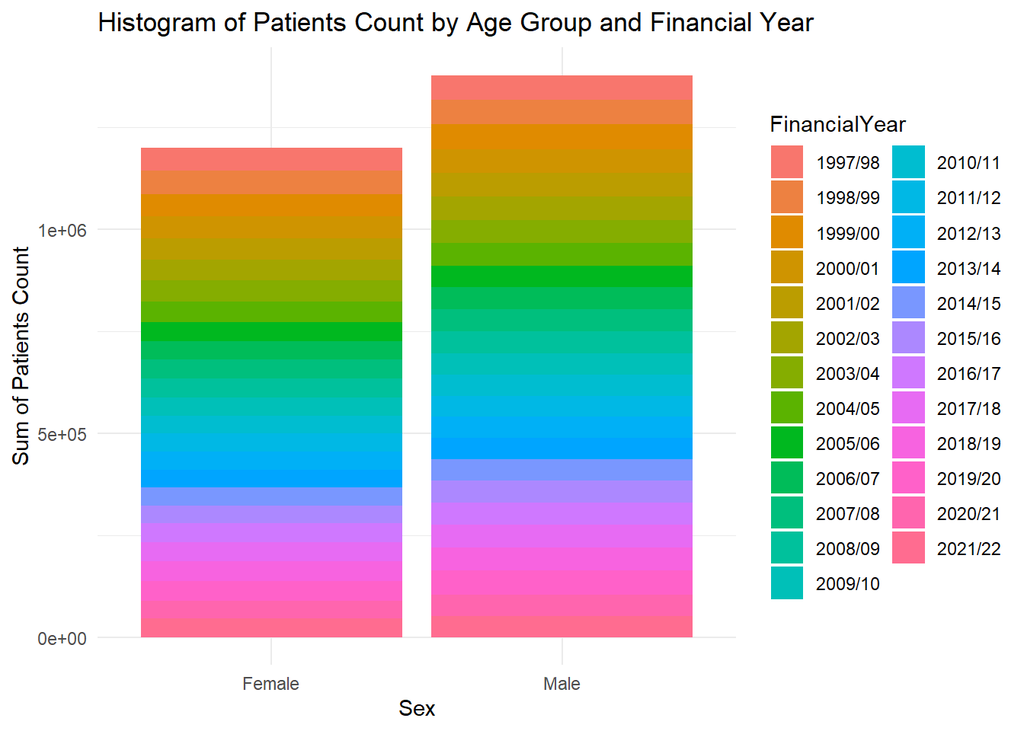

```r
#sex
age_and_sex_BUT_READABLE %>%
  group_by(FinancialYear, Sex) %>%
  summarise(Sum_PatientsCount = sum(PatientsCount, na.rm = TRUE), .groups = "keep") %>%

  ggplot(mapping = aes(x = Sex, y = Sum_PatientsCount, fill = FinancialYear)) +
  geom_col() +
  labs(title = "Histogram of Patients Count by Age Group and Financial Year",
       x = "Sex",
       y = "Sum of Patients Count") +
  theme_minimal()
```

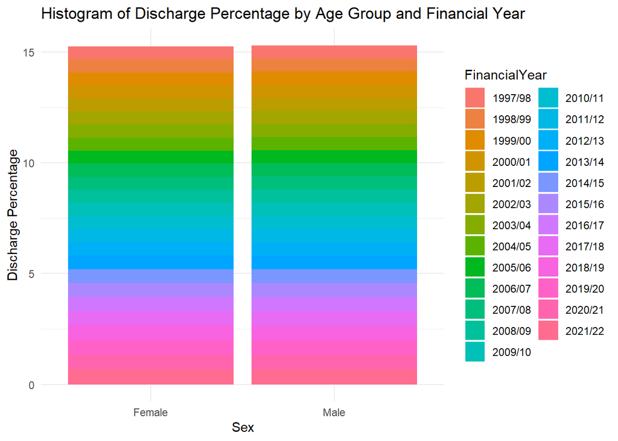

```r
age_and_sex_BUT_READABLE %>%
  mutate(TotalPatientsCount = DischargeCount + PatientsCount)  %>%
  group_by(FinancialYear, Sex) %>%
  summarise(DischargeCountPercentage = sum(DischargeCount) / sum(TotalPatientsCount, na.rm = TRUE), .groups = "keep") %>%

  ggplot(mapping = aes(x = Sex, y = DischargeCountPercentage, fill = FinancialYear)) +
  geom_col() +
  labs(title = "Histogram of Discharge Percentage by Age Group and Financial Year",
       x = "Sex",
       y = "Discharge Percentage") +
  theme_minimal()
```

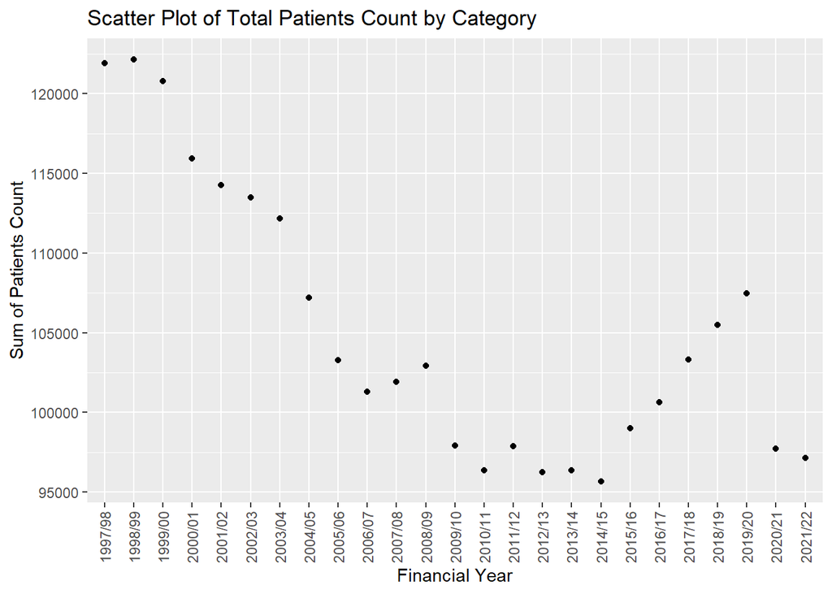

```r
#icd_categories
diagnosis_BUT_READABLE %>%
  group_by( FinancialYear) %>%
  summarise(Sum_PatientsCount = sum(PatientsCount, na.rm = TRUE), .groups = "keep") %>%

  ggplot(mapping = aes(x = FinancialYear, y = Sum_PatientsCount)) +
  geom_point() +
  labs(title = "Scatter Plot of Total Patients Count by Category",
       x = "Financial Year",
       y = "Sum of Patients Count") +
  theme(axis.text.x = element_text(angle = 90, vjust = 0.5, hjust = 1)) +
  scale_x_discrete(labels = function(x) str_wrap(x, width = 6))
```

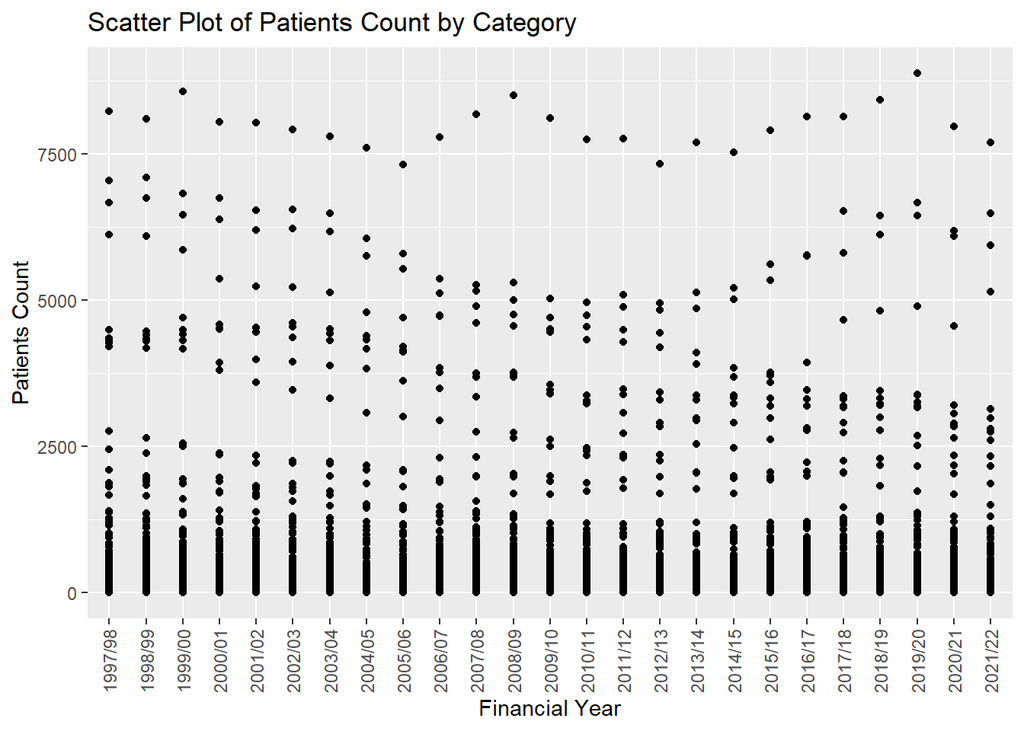

```r
diagnosis_BUT_READABLE %>%
  ggplot(mapping = aes(x = FinancialYear, y = PatientsCount)) +
  geom_point() +
  labs(title = "Scatter Plot of Patients Count by Category",
       x = "Financial Year",
       y = "Patients Count") +
  theme(axis.text.x = element_text(angle = 90, vjust = 0.5, hjust = 1)) +
  scale_x_discrete(labels = function(x) str_wrap(x, width = 6))
```

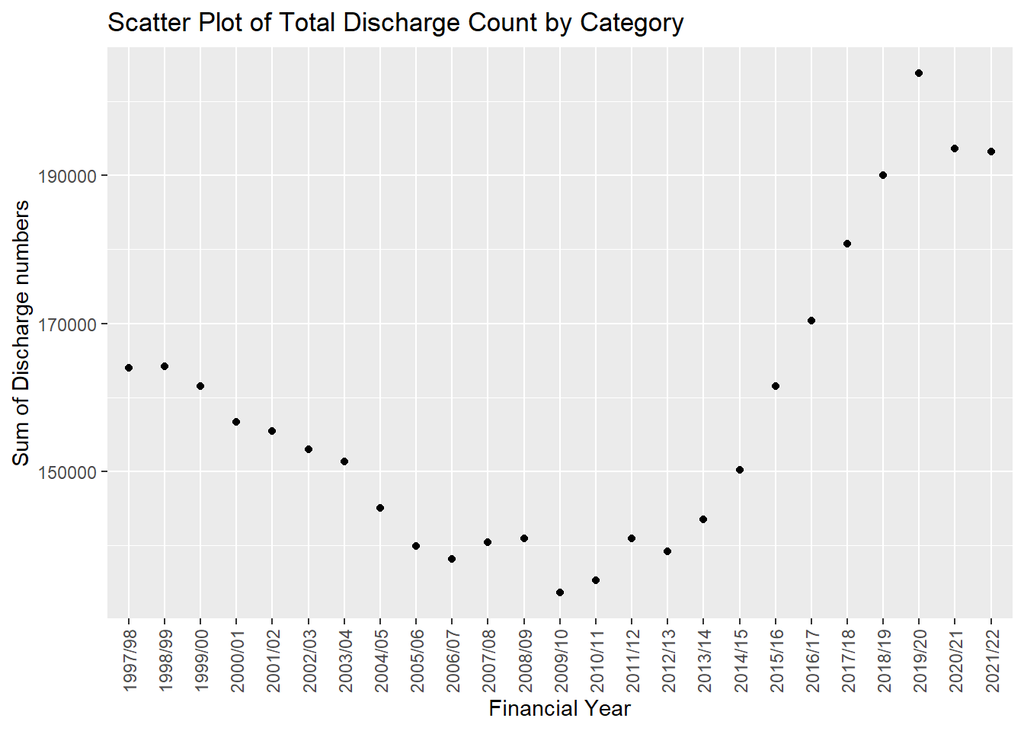

```r
diagnosis_BUT_READABLE %>%
  group_by(FinancialYear) %>%
  summarise(Sum_DischargeCount = sum(DischargeCount, na.rm = TRUE), .groups = "keep") %>%

  ggplot(mapping = aes(x = FinancialYear, y = Sum_DischargeCount)) +
  geom_point() +
  labs(title = "Scatter Plot of Total Discharge Count by Category",
       x = "Financial Year",
       y = "Sum of Discharge numbers") +
  theme(axis.text.x = element_text(angle = 90, vjust = 0.5, hjust = 1)) +
  scale_x_discrete(labels = function(x) str_wrap(x, width = 6))
```

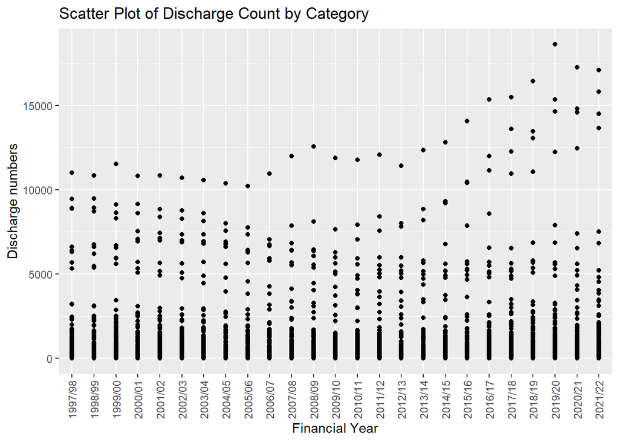

```r
diagnosis_BUT_READABLE %>%
  ggplot(mapping = aes(x = FinancialYear, y = DischargeCount)) +
  geom_point() +
  labs(title = "Scatter Plot of Discharge Count by Category",
       x = "Financial Year",
       y = "Discharge numbers") +
  theme(axis.text.x = element_text(angle = 90, vjust = 0.5, hjust = 1)) +
  scale_x_discrete(labels = function(x) str_wrap(x, width = 6))
```

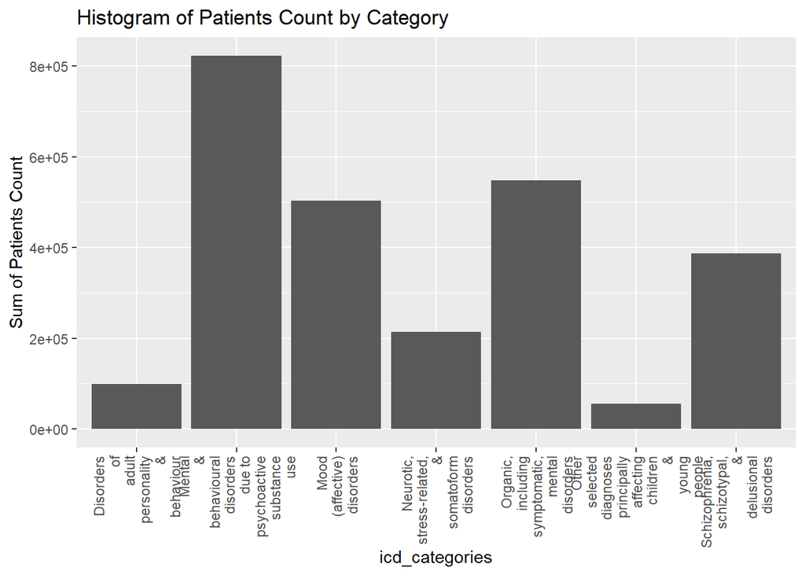

```r
#icd_categories
diagnosis_BUT_READABLE %>%
  group_by( icd_categories) %>%
  summarise(Sum_PatientsCount = sum(PatientsCount, na.rm = TRUE), .groups = "keep") %>%

  ggplot(mapping = aes(x = icd_categories, y = Sum_PatientsCount)) +
  geom_col() +
  labs(title = "Histogram of Patients Count by Category",
       x = "icd_categories",
       y = "Sum of Patients Count") +
  theme(axis.text.x = element_text(angle = 90, vjust = 0.5, hjust = 1)) +
  scale_x_discrete(labels = function(x) str_wrap(x, width = 6))
```

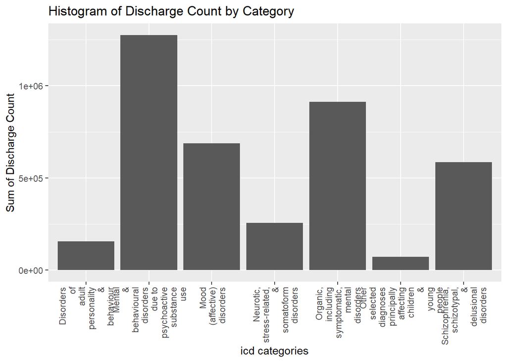

```r
diagnosis_BUT_READABLE %>%
  group_by( icd_categories) %>%
  summarise(Sum_DischargeCount = sum(DischargeCount, na.rm = TRUE), .groups = "keep") %>%

  ggplot(mapping = aes(x = icd_categories, y = Sum_DischargeCount)) +
  geom_col() +
  labs(title = "Histogram of Discharge Count by Category",
       x = "icd categories",
       y = "Sum of Discharge Count") +
  theme(axis.text.x = element_text(angle = 90, vjust = 0.5, hjust = 1)) +
  scale_x_discrete(labels = function(x) str_wrap(x, width = 6))
```

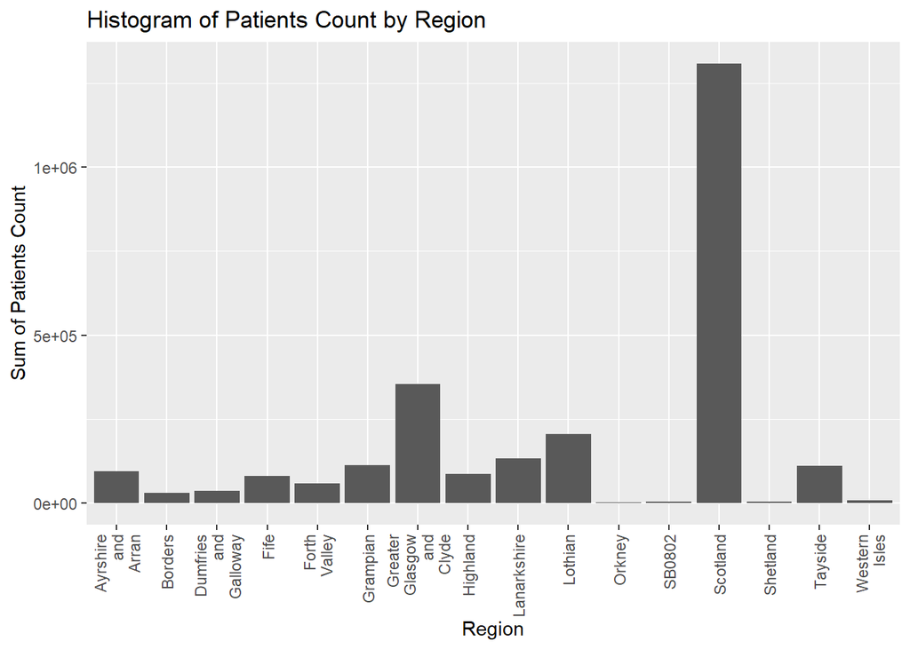

```r
# hbt_translated
diagnosis_BUT_READABLE %>%
  group_by( hbt_translated) %>%
  summarise(Sum_PatientsCount = sum(PatientsCount, na.rm = TRUE), .groups = "keep") %>%

  ggplot(mapping = aes(x = hbt_translated, y = Sum_PatientsCount)) +
  geom_col() +
  labs(title = "Histogram of Patients Count by Region",
       x = "Region",
       y = "Sum of Patients Count") +
  theme(axis.text.x = element_text(angle = 90, vjust = 0.5, hjust = 1)) +
  scale_x_discrete(labels = function(x) str_wrap(x, width = 6))
```

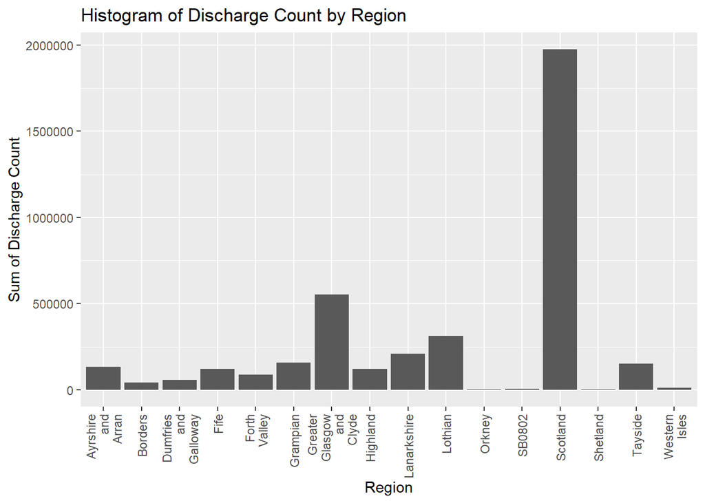

```r
diagnosis_BUT_READABLE %>%
  group_by(hbt_translated) %>%
  summarise(Sum_DischargeCount = sum(DischargeCount, na.rm = TRUE), .groups = "keep") %>%

  ggplot(mapping = aes(x = hbt_translated, y = Sum_DischargeCount)) +
  geom_col() +
  labs(title = "Histogram of Discharge Count by Region",
       x = "Region",
       y = "Sum of Discharge Count") +
  theme(axis.text.x = element_text(angle = 90, vjust = 0.5, hjust = 1)) +
  scale_x_discrete(labels = function(x) str_wrap(x, width = 6))
```

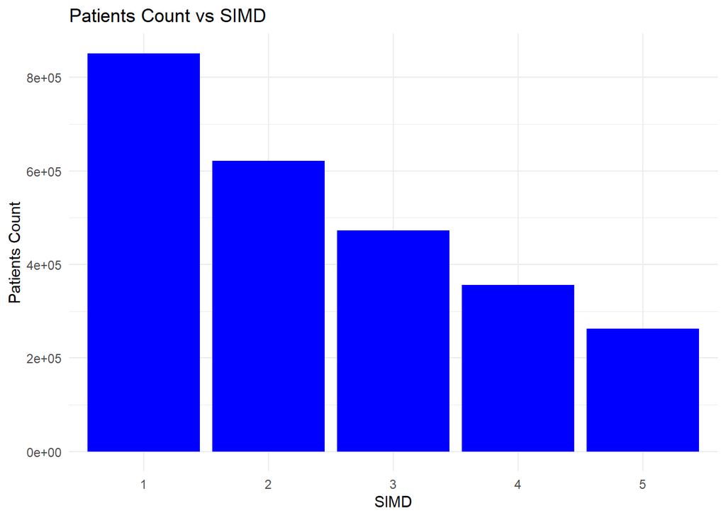

```r
#deprivation
deprivation_BUT_READABLE %>%
  group_by(SIMD) %>%
  summarise(TotalPatientsCount = sum(PatientsCount)) %>%
ggplot(aes(x = as.factor(SIMD), y = TotalPatientsCount)) +
  geom_bar(stat = "identity", fill = "blue") +
  labs(title = "Patients Count vs SIMD",
       x = "SIMD",
       y = "Patients Count") +
  theme_minimal()
```

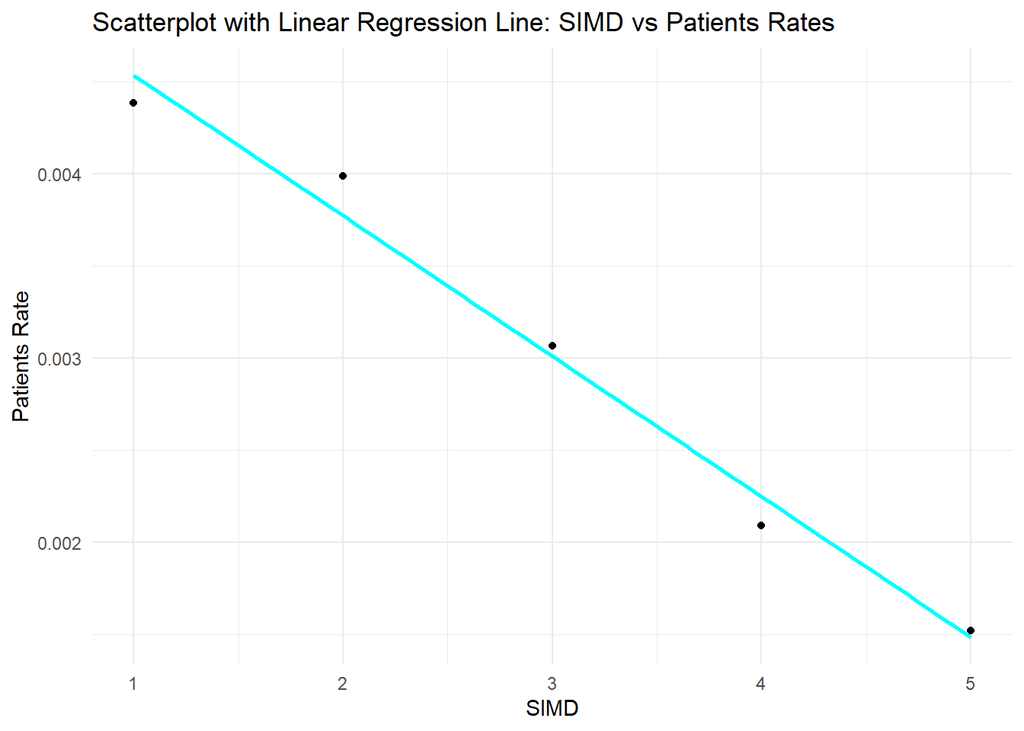

```r
deprivation_by_simd <- deprivation_BUT_READABLE %>%
                      group_by(SIMD) %>%
                      summarise(TotalPatientsRates = sum(PatientsRates) / (n()))

deprivation_by_simd %>%
  ggplot(mapping = aes(x = SIMD, y = TotalPatientsRates)) +
    geom_point() +
    geom_smooth(method = "lm", se = FALSE, color = "cyan") +
    labs(title = "Scatterplot with Linear Regression Line: SIMD vs Patients Rates",
         x = "SIMD",
         y = "Patients Rate") +
    theme_minimal()
```

```r
deprivation_lin_model <- linear_reg() %>%
  set_engine("lm") %>%
  fit(PatientsRates ~ SIMD, data = deprivation_BUT_READABLE)
tidy(deprivation_lin_model)
```

```
## # A tibble: 2 × 5
##   term         estimate std.error statistic   p.value
##   <chr>           <dbl>     <dbl>     <dbl>     <dbl>
## 1 (Intercept)  0.00529  0.0000620      85.3 0
## 2 SIMD        -0.000762 0.0000187     -40.7 4.46e-318
```

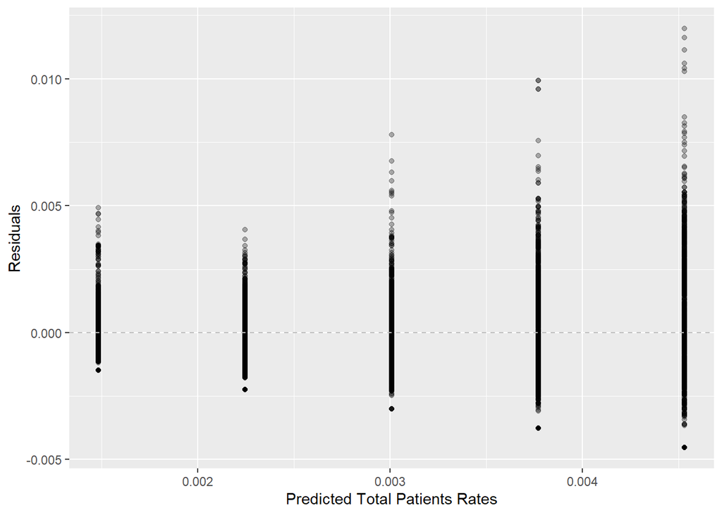

```r
deprivation_simd_lin_model_aug <- augment(deprivation_lin_model$fit)

ggplot(deprivation_simd_lin_model_aug, mapping = aes(x = .fitted, y = .resid)) +
  geom_point(alpha = 0.3) +
  geom_hline(yintercept = 0, color = "gray", lty = "dashed") +
  labs(x = "Predicted Total Patients Rates", y = "Residuals")
```

```r
diagnosis_pre_2011 <- diagnosis_BUT_READABLE %>%
  mutate(FinancialYear = strtoi (substring(FinancialYear, 1,4))) %>%
  filter(FinancialYear < 2011, FinancialYear < 2020) #this is exclusive

diagnosis_post_2011 <- diagnosis_BUT_READABLE %>%
  mutate(FinancialYear = strtoi (substring(FinancialYear, 1,4))) %>%
  filter(FinancialYear >= 2011 , FinancialYear < 2020) # this is inclusive
```

i am excluding 2020 and 2021, big drop largely due to covid

```r
diagnosis_pre_2011_lin_model <- linear_reg() %>%
  set_engine("lm") %>%
  fit(PatientsCount ~ FinancialYear, data = diagnosis_pre_2011)

diagnosis_pre_2011_lin_model
```

```
## parsnip model object
##
##
## Call:
## stats::lm(formula = PatientsCount ~ FinancialYear, data = data)
##
## Coefficients:
##   (Intercept)  FinancialYear
##     13735.290         -6.682
```

```r
diagnosis_post_2011_lin_model <- linear_reg() %>%
  set_engine("lm") %>%
  fit(PatientsCount ~ FinancialYear, data = diagnosis_post_2011)

diagnosis_post_2011_lin_model
```

```
## parsnip model object
##
##
## Call:
## stats::lm(formula = PatientsCount ~ FinancialYear, data = data)
##
## Coefficients:
##   (Intercept)  FinancialYear
##     -8733.332          4.492
```

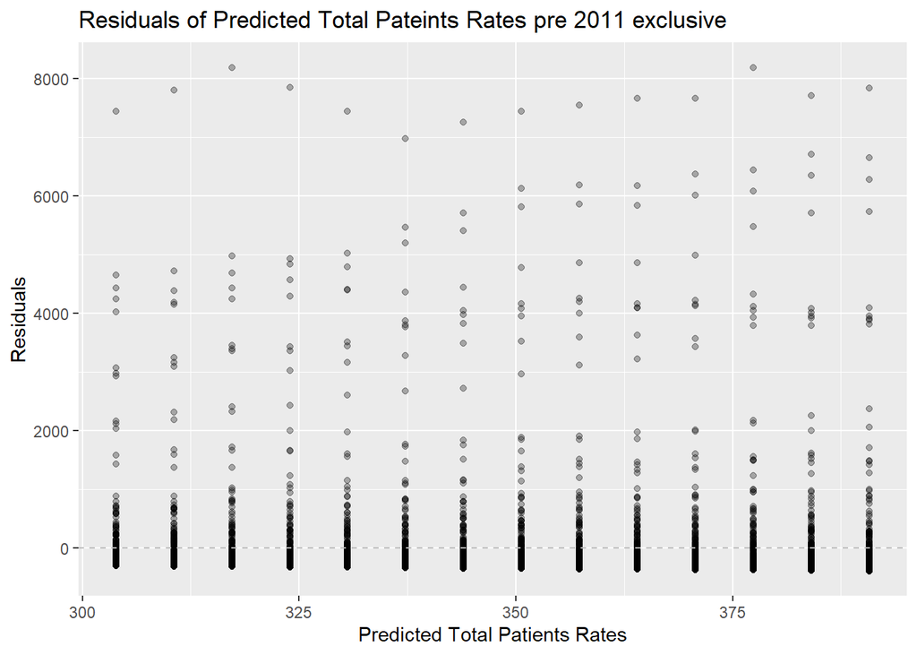

```r
diagnosis_pre_2011_lin_model_aug <- augment(diagnosis_pre_2011_lin_model$fit)

ggplot(diagnosis_pre_2011_lin_model_aug, mapping = aes(x = .fitted, y = .resid)) +
  geom_point(alpha = 0.3) +
  geom_hline(yintercept = 0, color = "gray", lty = "dashed") +
  labs(title = "Residuals of Predicted Total Pateints Rates pre 2011 exclusive", x = "Predicted Total Patients Rates", y = "Residuals")
```

[figure not shown]

```r
diagnosis_post_2011_lin_model_aug <- augment(diagnosis_post_2011_lin_model$fit)

ggplot(diagnosis_pre_2011_lin_model_aug, mapping = aes(x = .fitted, y = .resid)) +
  geom_point(alpha = 0.3) +
  geom_hline(yintercept = 0, color = "gray", lty = "dashed") +
  labs(title = "Residuals of Predicted Total Pateints Rates post 2011 inclusive", x = "Predicted Total Patients Rates", y = "Residuals")
```

```r
glance(diagnosis_pre_2011_lin_model)$r.squared
```

```
## [1] 0.0008965773
```

```r
glance(diagnosis_post_2011_lin_model)$r.squared
```

```
## [1] 0.000197397
```

Imma do it again but with the cumulative data again look at that r square lol

```r
diagnosis_pre_2011_cum <- diagnosis_pre_2011 %>% group_by(FinancialYear) %>% summarise(TotalPatientsCount = sum(PatientsCount, na.rm = TRUE))

diagnosis_post_2011_cum <- diagnosis_post_2011 %>% group_by(FinancialYear) %>% summarise(TotalPatientsCount = sum(PatientsCount, na.rm = TRUE))
```

```r
diagnosis_pre_2011_cum_lin_model <- linear_reg() %>%
  set_engine("lm") %>%
  fit(TotalPatientsCount ~ FinancialYear, data = diagnosis_pre_2011_cum)

diagnosis_pre_2011_cum_lin_model
```

```
## parsnip model object
##
##
## Call:
## stats::lm(formula = TotalPatientsCount ~ FinancialYear, data = data)
##
## Coefficients:
##   (Intercept)  FinancialYear
##       4326616          -2105
```

```r
diagnosis_post_2011_cum_lin_model <- linear_reg() %>%
  set_engine("lm") %>%
  fit(TotalPatientsCount ~ FinancialYear, data = diagnosis_post_2011_cum)

diagnosis_post_2011_cum_lin_model
```

```
## parsnip model object
##
##
## Call:
## stats::lm(formula = TotalPatientsCount ~ FinancialYear, data = data)
##
## Coefficients:
##   (Intercept)  FinancialYear
##      -2750999           1415
```

[figure not shown]

```r
diagnosis_pre_2011_cum_lin_model_aug <- augment(diagnosis_post_2011_cum_lin_model$fit)

ggplot(diagnosis_pre_2011_lin_model_aug, mapping = aes(x = .fitted, y = .resid)) +
  geom_point(alpha = 0.3) +
  geom_hline(yintercept = 0, color = "gray", lty = "dashed") +
  labs(title = "Residuals of Predicted Total Pateints Rates pre 2011 exclusive", x = "Predicted Total Patients Rates", y = "Residuals")
```

[figure not shown]

```r
diagnosis_post_2011_cum_lin_model_aug <- augment(diagnosis_post_2011_cum_lin_model$fit)

ggplot(diagnosis_pre_2011_lin_model_aug, mapping = aes(x = .fitted, y = .resid)) +
  geom_point(alpha = 0.3) +
  geom_hline(yintercept = 0, color = "gray", lty = "dashed") +
  labs(title = "Residuals of Predicted Total Pateints Rates post 2011 inclusive", x = "Predicted Total Patients Rates", y = "Residuals")
```

```r
glance(diagnosis_pre_2011_cum_lin_model)$r.squared
```

```
## [1] 0.963175
```

```r
glance(diagnosis_post_2011_cum_lin_model)$r.squared
```

```
## [1] 0.810157
```

```r
set.seed(1116)
diagnosis_pre_2011 <- na.omit(diagnosis_pre_2011)
diagnosis_pre_2011_split <- initial_split(diagnosis_pre_2011, prop = 0.80)

pre_train_data <- training(diagnosis_pre_2011_split)
pre_test_data <- testing(diagnosis_pre_2011_split)


pre_rec <- recipe(PatientsCount ~ FinancialYear, data = pre_train_data) %>%
  step_dummy(all_nominal(), -all_outcomes())

pre_mod <- linear_reg() %>%
  set_engine("lm")

pre_workflow <- workflow() %>%
  add_model(pre_mod) %>%
  add_recipe(pre_rec)

pre_fit <- pre_workflow %>%
  fit(data = pre_train_data)

pre_pred <- predict(pre_fit, pre_test_data) %>%
  bind_cols(pre_test_data)
pre_pred
```

```
## # A tibble: 510 × 11
##    .pred FinancialYear DischargeCount DischargeRates PatientsCount PatientsRates
##    <dbl>         <int>          <dbl>          <dbl>         <dbl>         <dbl>
##  1  615.          1997           1230      0.000242            850     0.000167
##  2  615.          1997           1170      0.000230            810     0.000159
##  3  615.          1997           5680      0.00112            4300     0.000846
##  4  602.          1998           1360      0.000268            930     0.000183
##  5  602.          1998           9470      0.00187            7100     0.00140
##  6  602.          1998           8710      0.00172            6100     0.00120
##  7  602.          1998            470      0.0000926           420     0.0000827
##  8  588.          1999           9130      0.00180            6820     0.00134
##  9  588.          1999           2190      0.000432           1880     0.000371
## 10  574.          2000           1990      0.000393           1740     0.000344
## # ℹ 500 more rows
## # ℹ 5 more variables: HospitalResidentsCount <dbl>,
## #   HospitalResidentsRates <dbl>, icd_categories <chr>, smr_translated <chr>,
## #   hbt_translated <chr>
```

```r
rsq(pre_pred, truth = PatientsCount, estimate = .pred)
```

```
## # A tibble: 1 × 3
##   .metric .estimator .estimate
##   <chr>   <chr>          <dbl>
## 1 rsq     standard    0.000458
```

```r
rmse(pre_pred, truth = PatientsCount, estimate = .pred)
```

```
## # A tibble: 1 × 3
##   .metric .estimator .estimate
##   <chr>   <chr>          <dbl>
## 1 rmse    standard        951.
```

```r
folds <- vfold_cv(pre_train_data, v = 5)
folds
```

```
## #  5-fold cross-validation
## # A tibble: 5 × 2
##   splits             id
##   <list>             <chr>
## 1 <split [1630/408]> Fold1
## 2 <split [1630/408]> Fold2
## 3 <split [1630/408]> Fold3
## 4 <split [1631/407]> Fold4
## 5 <split [1631/407]> Fold5
```

```r
set.seed(456)
pre_fit_rs <- pre_workflow %>%
  fit_resamples(folds)
pre_fit_rs
```

```
## # Resampling results
## # 5-fold cross-validation
## # A tibble: 5 × 4
##   splits             id    .metrics         .notes
##   <list>             <chr> <list>           <list>
## 1 <split [1630/408]> Fold1 <tibble [2 × 4]> <tibble [0 × 3]>
## 2 <split [1630/408]> Fold2 <tibble [2 × 4]> <tibble [0 × 3]>
## 3 <split [1630/408]> Fold3 <tibble [2 × 4]> <tibble [0 × 3]>
## 4 <split [1631/407]> Fold4 <tibble [2 × 4]> <tibble [0 × 3]>
## 5 <split [1631/407]> Fold5 <tibble [2 × 4]> <tibble [0 × 3]>
```

```r
collect_metrics(pre_fit_rs, summarize = FALSE)
```

```
## # A tibble: 10 × 5
##    id    .metric .estimator   .estimate .config
##    <chr> <chr>   <chr>            <dbl> <chr>
##  1 Fold1 rmse    standard   1081.       Preprocessor1_Model1
##  2 Fold1 rsq     standard      0.00152  Preprocessor1_Model1
##  3 Fold2 rmse    standard   1369.       Preprocessor1_Model1
##  4 Fold2 rsq     standard      0.00916  Preprocessor1_Model1
##  5 Fold3 rmse    standard   1051.       Preprocessor1_Model1
##  6 Fold3 rsq     standard      0.0130   Preprocessor1_Model1
##  7 Fold4 rmse    standard   1110.       Preprocessor1_Model1
##  8 Fold4 rsq     standard      0.000629 Preprocessor1_Model1
##  9 Fold5 rmse    standard    947.       Preprocessor1_Model1
## 10 Fold5 rsq     standard      0.00295  Preprocessor1_Model1
```

after goign through this once, we realise that it doesnt work lol its not very correlatable and it isi bad, it is better to do it through simmply the cumalative one in every way, quick kenny write a pragraph explain it